# R in the World of Education

Erin Grand  
December 12, 2017

R-Ladies NYC

### About Me

- Studied Astronomy and Physics at University of Maryland
- Data Science MS from Columbia University 2011
- Currently Associate Director of Data Analytics at Uncommon Schools

[figure not shown]

### What is a charter school?

*A charter school is an independently run public school granted greater flexibility in its operations, in return for greater accountability for performance. The “charter” establishing each school is a performance contract detailing the school's mission, program, students served, performance goals, and methods of assessment.*

### Uncommon Schools

[figure not shown]

- Established in 1997 (oldest school opened - North Star Academy in Newark); 2005 - CMO formed
- 83% Free and reduced meal population
- Intensive PD for teachers & leaders; Partnerships with local districts to deliver PD; Summer Teaching Fellows diversity recruitment program; Camp Uncommon

### What kind of data do we work with?

- **Assessments**: Interim assessments
- **Exams**: Common Core aligned state exams, SAT, PSAT, APs, …etc
- **Classroom**: Grades, attendance, suspensions, …etc
- **Teacher**: student - course - teacher linkage
- **Staff Data**: HR and Recruitment

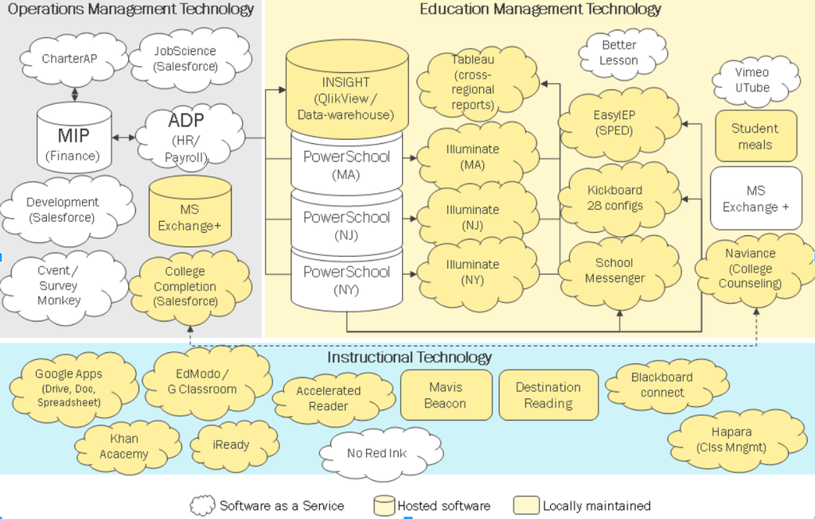

### Data Challenges

- Missing/Incomplete data
- Different data sources without matching IDs (i.e HR to Teacher to Student)
- Students and teachers may move between schools or courses
- Alignment of data and data processes across all schools and regions
- Changing student IDs (not many)
- Human data reporting error
- Historical data quality

### Data Challenges We Can Fix!

- Messy excel sheets (historical or human entered)
- Column names that don't apply anymore
- Lack of historical documentation
- Finding duplicate exams
- Students take half of one test and the other half of another
- Vanishing leading zeros
- Tracking of student IDs that change
- Common definitions (i.e “cohort”)
- How to refer to school years or school abbreviations
- Data audits

### Looking at Duplicates with Janitor

*Janitor was built with beginning-to-intermediate R users in mind and is optimized for user-friendliness. Advanced users can already do everything covered here, but they can do it faster with janitor and save their thinking for more fun tasks.* (*Sam Firke*)

If you're experienced with Tidyverse in general, you should be able to do everything inside janitor on your own, but we don't have the time to always clean up data without help.

[figure not shown]

### Benefits to using Janitor over writing your own code

- Functions are tested
- Generally obeys Hadley's official style guide
- Turn many lines of code into one or two
- Pipe-able functions
- Written for the education data space

### Messy Excel Sheets

[figure not shown]

*Image credit to Sam Firke*

### Using Janitor to Clean Excel

```r
read_excel(filepath, sheet="Sheet1", col_types = "text") %>%
  clean_names() %>%
  remove_empty_cols() %>%
  remove_empty_rows() %>%
  mutate_at(vars(entrydate, exitdate, student_id, yearsinuncommon), as.numeric) %>%
  mutate_at(vars(entrydate, exitdate), excel_numeric_to_date)
```

### Finding Duplicates

```r
library(tidyverse)
library(janitor)
library(readxl)

students <- read_excel(filepath, sheet="Sheet1", col_types = "text") %>%
  clean_names() %>%
  remove_empty_cols() %>%
  mutate_at(vars(entrydate, exitdate, student_id, yearsinuncommon), as.numeric) %>%
  mutate_at(vars(entrydate, exitdate), excel_numeric_to_date)
```

```r
students %>%
  get_dupes(student_id)
```

```
# A tibble: 2 x 6
  student_id dupe_count grade yearsinuncommon  entrydate   exitdate
       <dbl>      <int> <dbl>           <dbl>     <date>     <date>
1    7851976          2     5               1 2017-11-12 2017-12-12
2    7851976          2     6               1 2017-11-12 2017-12-12
```

### Now What?

- Correct the dupes individually with `if_else` or `case_when`

```
mutate(students, grade = if_else(student_id == 7851976, 5, grade))
```

- Summarize by taking minimum date / grade, if that is causing the problem

```r
group_by(students, student_id) %>% summarize(grade = min(grade))
```

- Output the duplicates and manually choose which version to keep

```r
dupes_correct <- read_csv("dupes_correct.csv")
left_join(students, dupes_correct) %>%
  replace_na(list(keep = 0)) %>%
  assert(not_na, keep) %>%
  filter(keep = 0)
```

### Managing Data Changes

Using `get_dupes` and `verify()` from the **assertr** package is a great way to put in checks in case the data changes (which it will).

```
check <- students %>%
  get_dupes(student_id) %>%
  verify(nrow(.) == 0)
```

If a student ID changes, or new duplicates occur, the code will HALT at this step alerting that something is off.

### Introducing R to my Team

**Learnings Along the Way**

- Choose the packages that are needed every day
- Have someone that is active in R community, so that you can be on the cutting edge.
- The more practice someone has, the faster they'll learn. Pair PD sessions with coding projects.

[figure not shown]

Model Building

### Automation of State Tests

Entire state test analyses from raw data to dashboard is done with scripts (push button analysis)

- Gathering, cleaning and basic processing

```r
files <- list.files("../Input/", pattern = ".xlsx", full.names =  TRUE)
nys <- map_dfr(files, prep_nys_files)
```

- Combine historical and new data from all three states
- Data is outputted into Tableau dashboards

### Cut Scores: Predicted Pass Rates

```r
library(rpart)
library(rpart.plot)

# Model Fit
fit <- rpart(proficient ~ ia_score, data=dat,  maxdepth = 1, method= "class")

# Accuracy Calculation
root.node.error <- fit$frame[1, 'dev']/fit$frame[1, 'n']
xerr <- min(fit$cptable[, 3])
cp.err <- root.node.error * xerr
acc <- round(1 - cp.err, 3)

# First Split
cut_score <- as.data.frame(fit$splits)$index
```

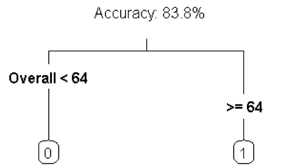

```r
# Plot Tree
prp(fit, fallen.leaves = TRUE, type = 3,
    extra = 1, under = TRUE, varlen=0, faclen=0)
title(sub = paste("Accuracy:", paste(100 * acc, "%", sep="")))
```

### Other Model Projects

- SGI (small group learning)
- Recruitment projections: Projected Attrition + Projected Growth
- Teacher Effect : Value added model(s)

Q & A

@astroeringrand